# What Role does Education Play in Voting

Zihan Chen

2020/9/29

[figure not shown]

## I. Introduction

As the 2020 election is approching, politics and election issue has become casual topic nowadays. People discuss together and determine which party they are going to vote for. As individual voter, one should take all aspects into consideration to make a better choice, while as a data scientist, one should try to find something beneath the data or to be specific some potential voting patterns.

The American National Election Studies (ANES) conduct surveys of voters in the U.S. on the national scale since 1948. They asked questions in their survey, including daily behaviors, polictial tendency and so on. It is so comprehensive that any single related field is also worth exploring. On coincidence, the National Basketball Assosication reopens after the quarantine and every player print slogan on their suits. The Boston Celtics focuses on voting and education reform which inspired me a lot.

[figure not shown]

Also, education for people in different races varies and may cause bias in the analysis. This potential bias is inevitable but should be rounded to the smallest. Thus, to take a deeper look at the role education played in voting and discover patterns between education and other fields, this project will be mainly on the effect of education for some certain race people.

## II. Data and Selection

The data is from The American National Election Studies (ANES), and it is of high dimension. This project extracts crutial features such as voting_turnout, race, income and so on. As is illustrated above, the quality and availability of education differs from races to races, so we first take a look at the number of respondents of different races.

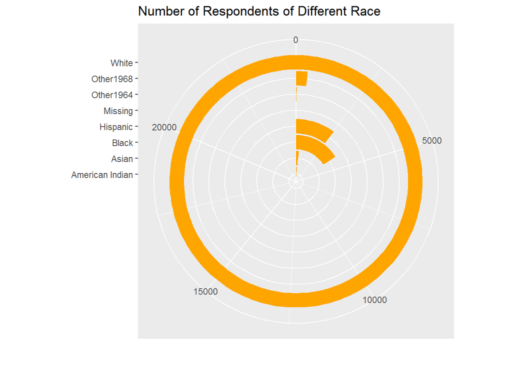

From the above Figure, people taking the ANES survey were mainly white, and respondents of other races are far fewer than whites. So, this project decides to only extract survey answers from the whites to do later on researches. And the final number of respondents will come to 24611, which is still big enough to simulate normal people’s behavior.

### III. How do Education Affects Voting?

We first take a closer look at the discription of education variable.

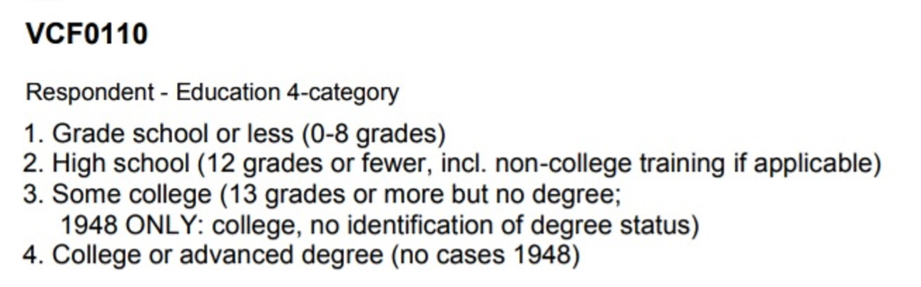

Actually there are different variables describing the education level of respondents, and VCF0110 itself is one of them. Compared to others, VCF0110 prevails with simplicity and clearity. We should never distinguish poeple in top universities from those in average ones, however education grades should be the only criteria.

After learning from the education level, the first thing to check is whether there exist a kind of tendency for under-educated or well-educated. As the following Figure shows, people who took less than 8 grades may have a good chance voting for nothing. Also, the more one is educated, the less the probability of not voting for president is.

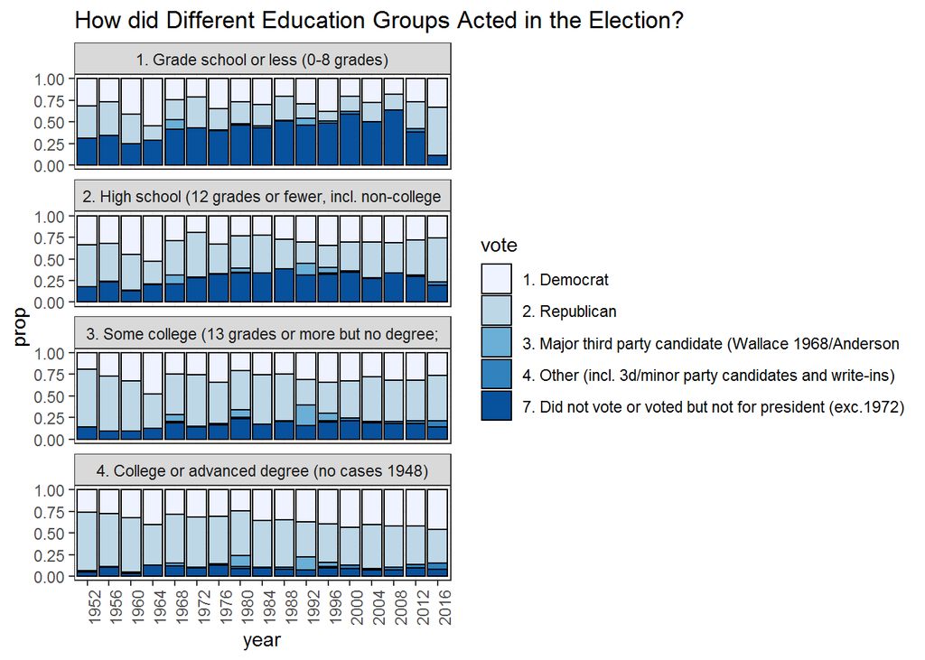

In addition, the third feature “3.Major third party” only appears in 1968,1980 and is especially significant in 1992. To explain this, some important global issue may help. Taking 1992 as an example, first of all, the cold war is over with the disintegration of Soviet Union. Together with the end of gulf war, it makes military competition over, and the United States faced Economy problem. In this situation, some people supported the wealthy businessman Ross Perot. In this way, effects from wars and economy largely affected people’s voting behavior and that is not what we want since it is not common.

Also, the sudden decrease in graph 1 at 2012 and 2016 is conspicious, to explain this, we change the graph structure, ploting the component of supporters for each party.

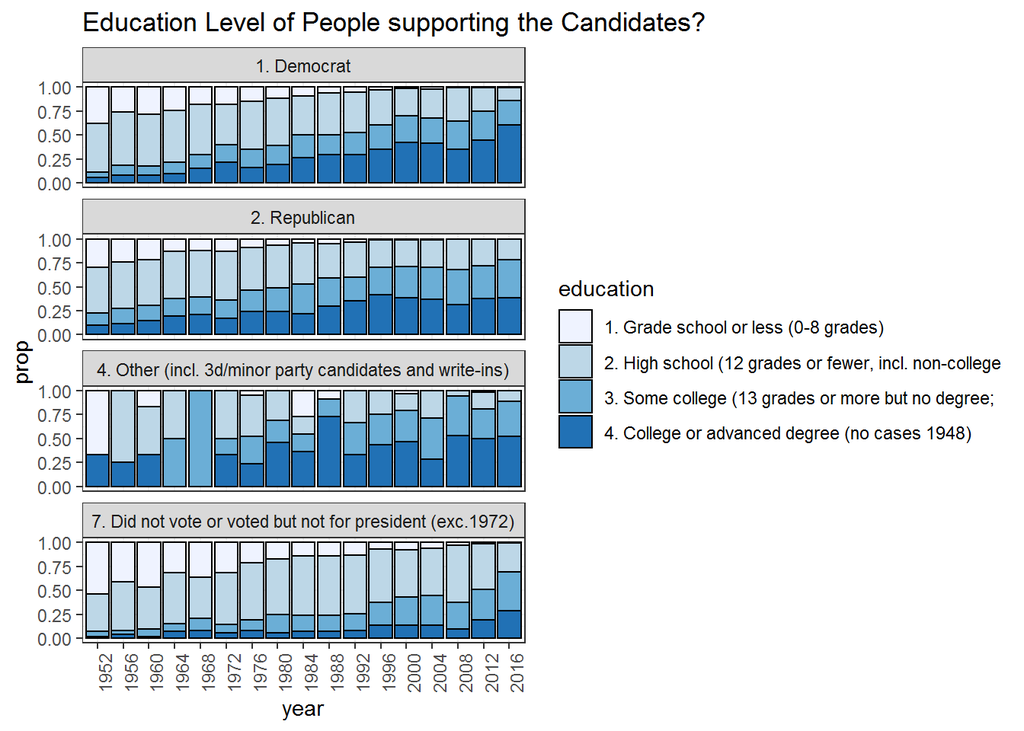

From this perspective, we see that the voters for group “others, including the third party” is chaotic, which coincides with reality, for the reason that the election is mainly the competition between the Democrat and the Republican, voters for the third party make up little percentage of the whole, and such small number may less likely to create patterns.

And to see voters for Democrat, Republican and Not voting, people with education level 8 or less become fewer and fewer in all the 3 groups, which may result from the total number of under-educated is becoming less. The Democrat attrachs more well-educated than Republican, which mostly rely on people graduating from high school and some college.

To explain the sudden decrease in graph 1 at 2012 and 2016, and varify the education development, the education level plot follows:

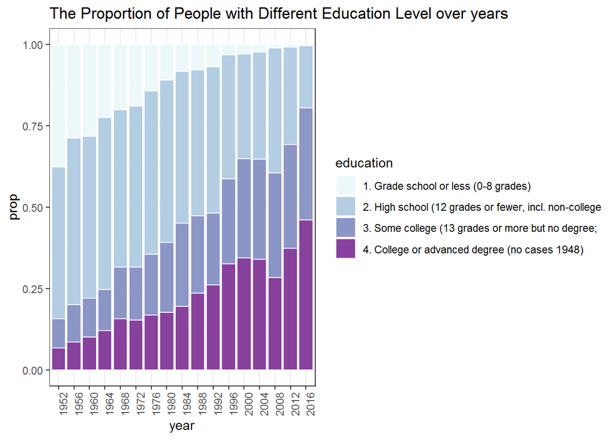

It is quite clear that the education level of people keeps improving for decades, and in 2016, number of people with 8 or less grade is so small that can be ignored, which perfectly explained that sudden decrease.

Notice that schools may emphasize the importance of voting, and emperically, the more one is educated, the more he is interested in and curious about politics, we want to check if the well-educated will take their voting rights, whoever they vote for. And the Figure follows.

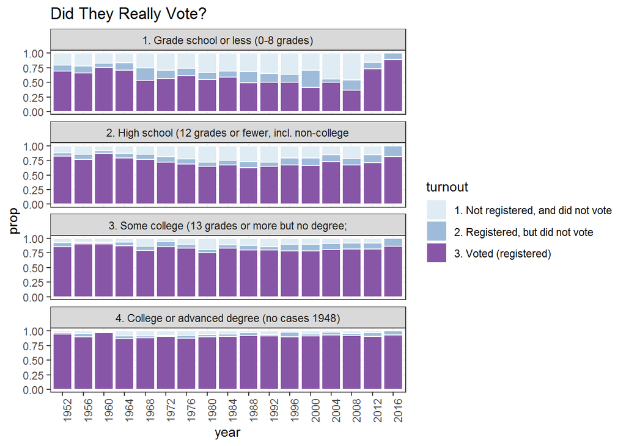

### IV. How do Education Relates to other Features?

Learning that Education has a big effect on voting behaviors, we would like to know whether there exists an relationship between education levels and other variables. From the following Figure , expect for education, income, interest and whether care win can be considered numeric variables while others are categorical, and to make variable numeric, we should get rid of those NAs. Keeping these numeric variables, we can calculate the covariance matrix to detect the inter-relationship.

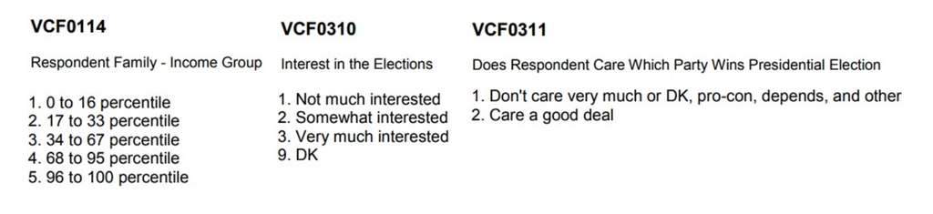

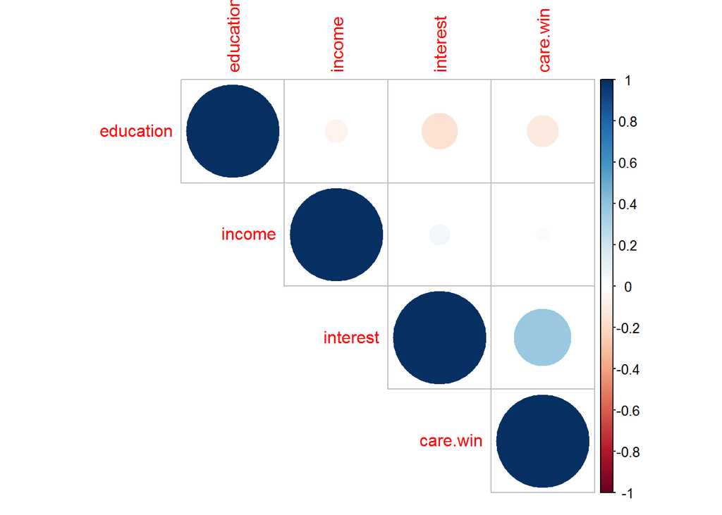

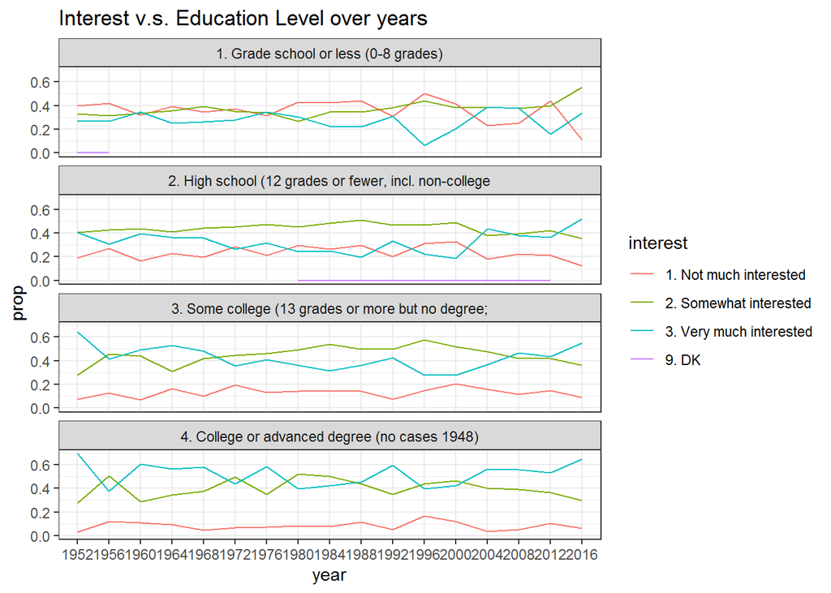

### IV. Votes Affected by Education together with other Features?

Finally, we want to know What is affected by education together with other features. Needless to say, relatively large absolute value of correlation will bring colinearity to data analysis. Following the correlation plot, we continue on checking the coeffect on voting from the combination of education and income group. The proportion Figure follows:

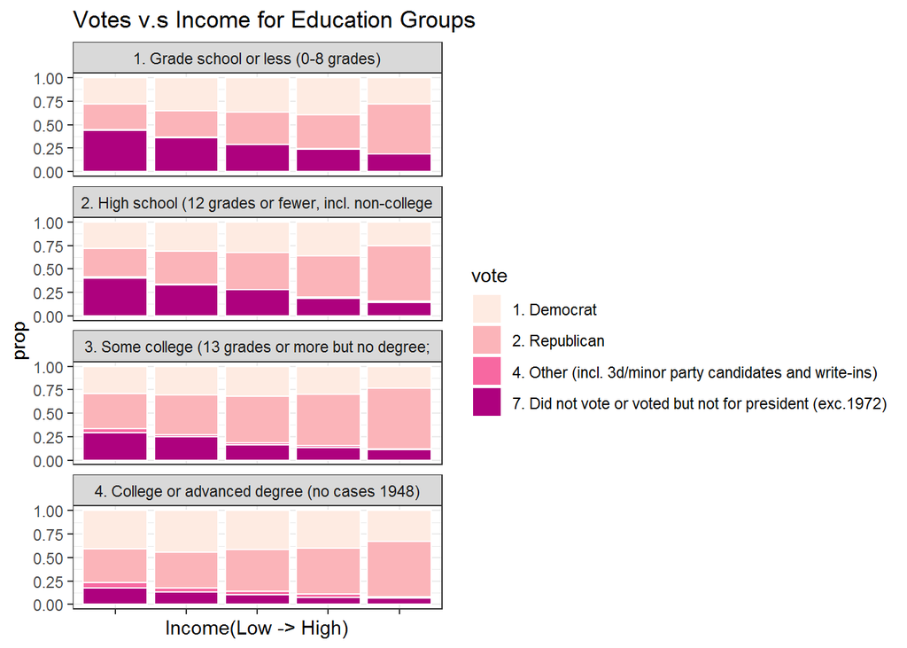

We can detect obvious pattern in Figure, but the trend is alike in the four group, or to be more specific, it acts like a meanshift from the same shape, which cannot be detected from correlation numerics. When choosing a single group, we can easily tell that wealthy people have a better chance of voting and their vote are more likely going to the Republican. From the other perspective, when keeping focus on a single column, the same thing happens with education level. That is well-educated will vote more, and their votes may go to the Democrat side.

Besides, education can make people more clear about themselves and reach a better self identification. Taking the self party identification as an example, people in different education group acts differently.

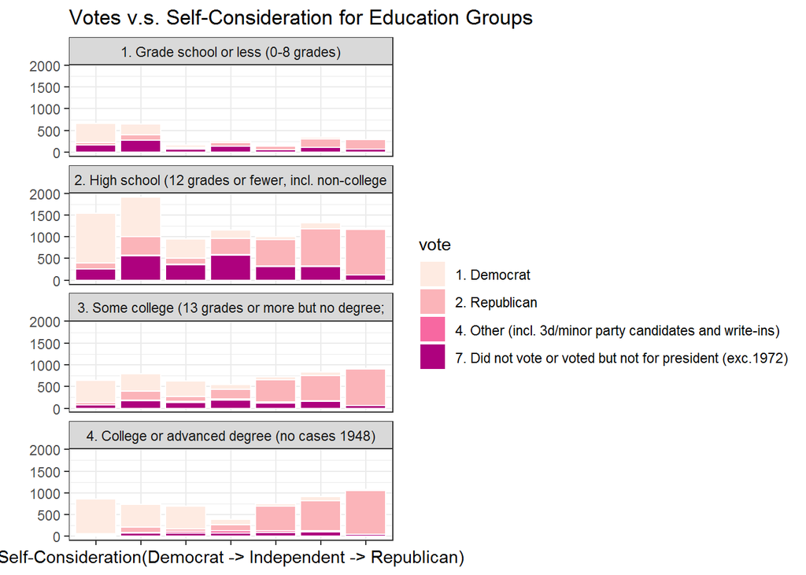

From Figure, People in college or have an advanced degree would have a clear self identification, only a small part defining themselves as independent. Also, Apart from those who did not vote, when well-educated people have already defined himself, his vote is almost there, and it is very rare for a self-defined Republican to vote for Democrat, vice versa. On the other hand, under-educated people may define themselves ambiguously and may make misleading self-portrait. Maybe an inspiring speech or a new policy can get them going to the othe end.

### V. Summary and Bias

Education makes a very important role in forming vote patterns, especially when combined with another categorical factor. The most significant part is that people find the importance of voting through education, and will truely think that their votes really count. However, the relationship between education and their voting party is somewhat not so clear, and maybe it can be explained by an intermediary feature instead of deucation, acting like a bridge. Not only for determining voting parties, education could also make oneself get a better self portrait, and act in his onw way, with little influence by others. Thus, education reform should indeed be properly undertook.

And to speak generally, there could be more specific questions such as the main reason for voting. For example, if when extracting all those choosing income for the main reason, we can then separate them into groups and reach a more comprehensive conclusion. Taking more features into consideration and getting more answers to link some of the features, more progress would be made in this studying field.